# matplotlib

- 1. Módulo Matplotlib
  - 1.1 Líneas. Función `plot`
    - 1.1.1 Opciones de estilo
  - 1.2 Histogramas. Función `hist`
  - 1.3 Diagramas de caja. Función `boxplot`
  - 1.4 Diagramas de dispersión. Función `scatter`
  - 1.5 Subgráficos

# 1. Módulo Matplotlib

La librería **matplotlib** ofrece métodos para la visualización de datos.

- Se trata de la librería gráfica de Python.
- La mayor parte de las funciones gráficas se encuentran en la sublibrería **pyplot**.

```python
import numpy as np                         # importación de numpy
import matplotlib as mpl                   # importación de matplotlib con alias mpl
import matplotlib.pyplot as plt
%matplotlib inline
```

## 1.1 Líneas. Función `plot`

Lo primero que vamos a hacer es generar los datos para después representarlos.

```python
# generación de datos
x = np.linspace(start=0, stop=2*np.pi, num=50)
y1 = np.sin(x)
y2 = np.cos(x)
```

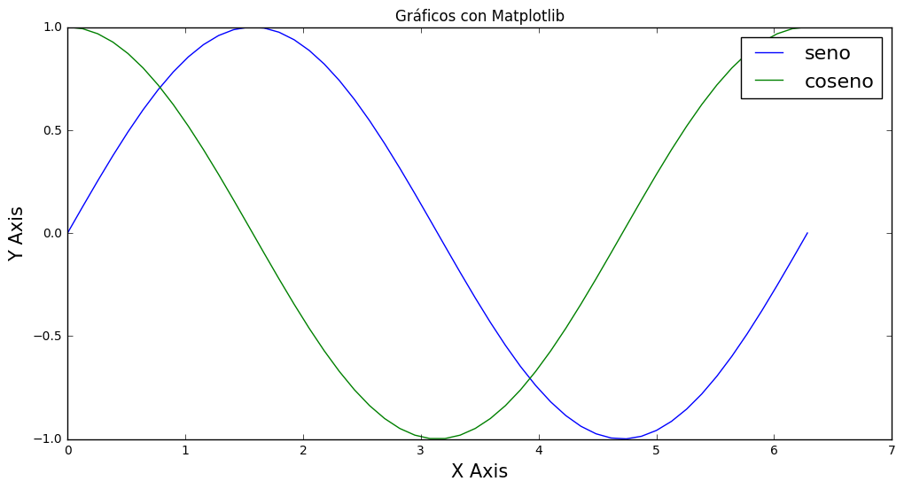

```python
fig, ax = plt.subplots(1, figsize=(12,6))
ax.plot(x, y1, label='seno')
ax.plot(x, y2, label='coseno')

ax.legend(fontsize=16)
ax.axes.xaxis.set_label_text("X Axis", fontdict={"size":15})
ax.axes.yaxis.set_label_text("Y Axis", fontdict={"size":15})
ax.title.set_text("Gráficos con Matplotlib")
```

### 1.1.1 Opciones de estilo

El estilo por defecto de las gráficas es muy simple, pero **matplotlib** ofrece un gran número de opciones que permiten cambiar y enriquecer el estilo.

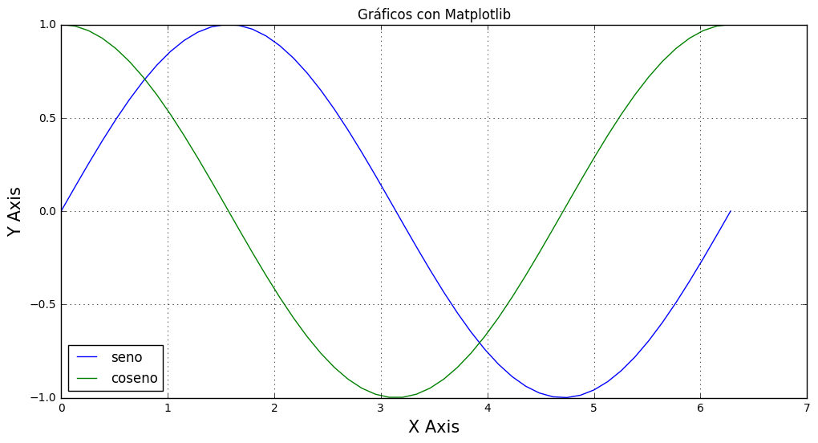

```python
fig, ax = plt.subplots(1, figsize=(12,6))
ax.grid(True)            # Opción: Pinta una cuadrícula en la gráfica

ax.plot(x, y1, label='seno')
ax.plot(x, y2, label='coseno')

ax.legend(fontsize=16)
ax.axes.xaxis.set_label_text("X Axis", fontdict={"size":15})
ax.axes.yaxis.set_label_text("Y Axis", fontdict={"size":15})
ax.title.set_text("Gráficos con Matplotlib")
ax.legend(loc=3);        # loc=0: El mejor sitio para colocar la leyenda
```

**Cambiando el estilo de representación**

Por defecto la función **plot** representa los datos mediante una línea continua de color azul. Si queremos representar los datos discretos mediante puntos, tan solo tenemos que cambiar las opciones de estilo.

Fíjate en la primera línea de código de la siguiente celda:

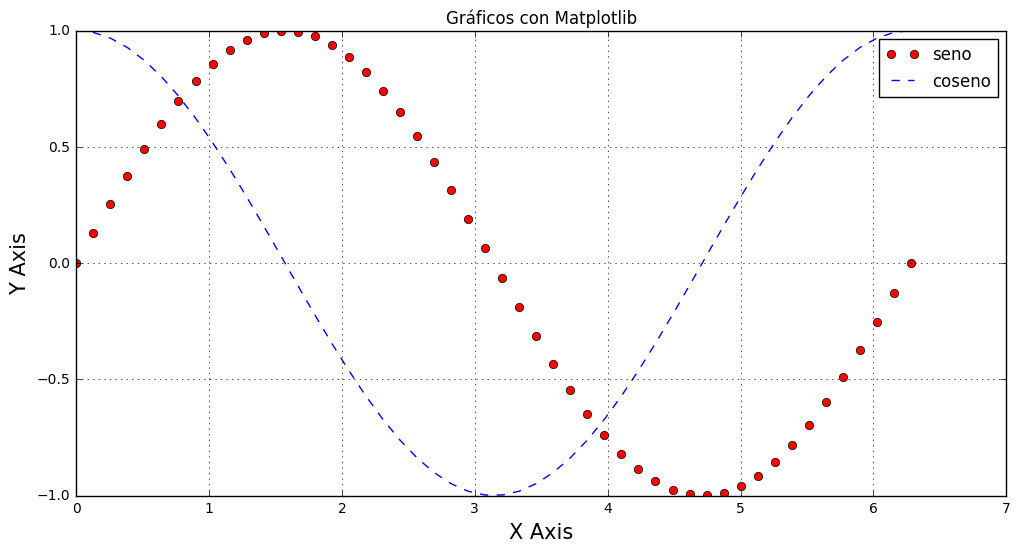

```python
fig, ax = plt.subplots(1, figsize=(12,6))
ax.grid(True)            # Opción: Pinta una cuadrícula en la gráfica

# pinta los datos con puntos (opción: 'o') rojos(opción:'r')
ax.plot(x, y1,'ro', label='seno')
ax.plot(x, y2, 'b--', label='coseno')

ax.legend(fontsize=16)
ax.axes.xaxis.set_label_text("X Axis", fontdict={"size":15})
ax.axes.yaxis.set_label_text("Y Axis", fontdict={"size":15})
ax.title.set_text("Gráficos con Matplotlib")
ax.legend(loc=0);        # loc=0: El mejor sitio para colocar la leyenda
```

- Los colores y estilos se pueden combinar de cualquier forma para distinguir diferentes conjuntos de datos.
- Los colores y estilos estándar son:

[figure not shown]

La locación de la leyenda se puede configurar:

[figure not shown]

## 1.2 Histogramas. Función `hist`

Permiten representar de forma gráfica una variable en forma de barras, donde cada barra es proporcional a la frecuencia de los datos representados. Creamos este tipo de gráficos con la función **hist**.

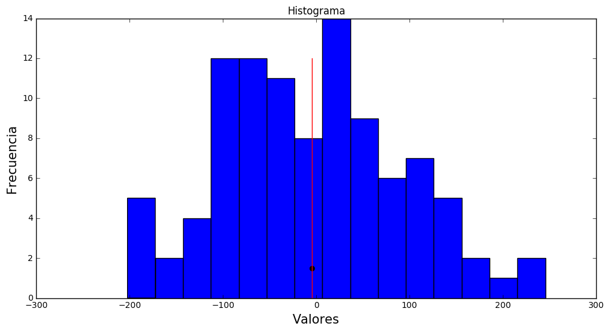

```python
datos = np.random.randn(100) * 100.0
media = datos.mean()              # media
desviacion = datos.std()          # desviación
m_y = 1.5

fig, ax = plt.subplots(1, figsize=(12,6))
ax.hist(datos, bins = 15)   # bin = número de barras a representar
ax.plot(media, m_y, "ko")
ax.plot([media, media] , [0, 12], "r"); # pinta una línea --

ax.set_title('Histograma')
ax.axes.xaxis.set_label_text("Valores", fontdict={"size":15})
ax.axes.yaxis.set_label_text("Frecuencia", fontdict={"size":15});
```

La función **plt.hist** soporta muchas opciones de configuración. El parámetro **bins** en la función permite indicar el número de barras a representar.

En el siguiente ejemplo optamos por representar las dos variables en la misma figura, cada una de ellas con su etiqueta (**label**):

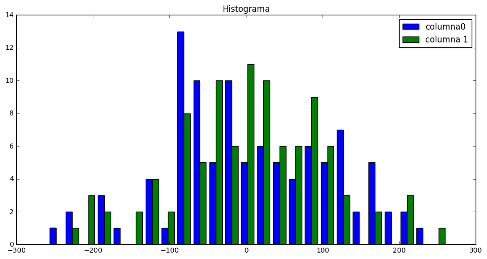

```python
datos = np.random.randn(100, 2) * 100.0     # 100 filas y 2 columnas

# Creamos una figura
fig, ax = plt.subplots(1, figsize=(12,6))

# representamos las dos variables en el mismo histograma
ax.hist(datos, label=['columna0', 'columna 1'], bins = 25)
ax.legend(loc=0)

ax.set_title('Histograma');
```

## 1.3 Diagramas de caja. Función `boxplot`

Este tipo de diagramas se construyen mediante la función **boxplot**.

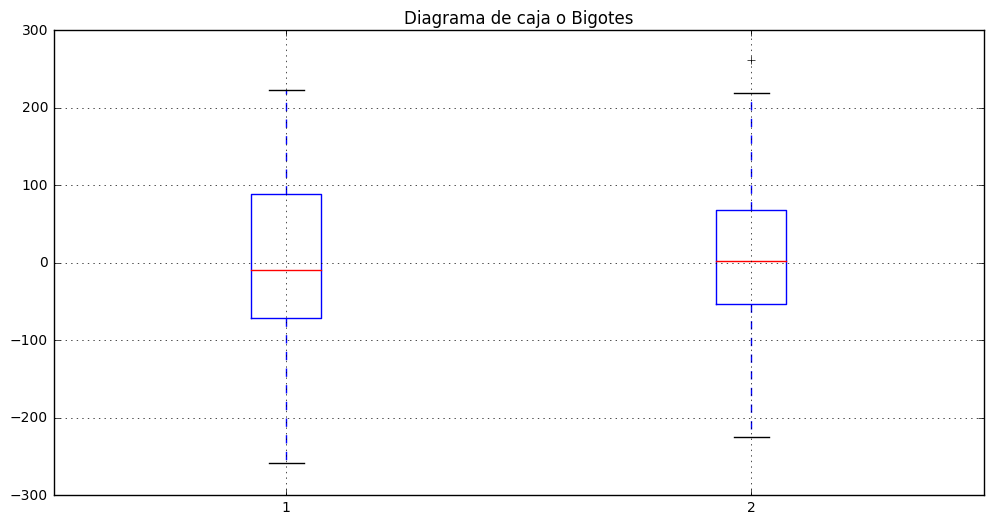

```python
# Creamos una figura
fig, ax = plt.subplots(1, figsize=(12,6))

plt.figure(figsize=(7,3))
ax.boxplot(datos)

ax.grid(True)
ax.set_title('Diagrama de caja o Bigotes')

ax.set_xticks([1, 2],[ 'Columna 1', 'Columna 2']);


fig.savefig('mi_boxplot1.pdf')     # para guardar los gráficos
fig.savefig('mi_boxplot2.png');
```

La función **plt.savefig** permite guardar los gráficos en diferentes formatos (pdf, png, ps, etc).

## 1.4 Diagramas de dispersión. Función `scatter`

Se usa habitualmente para observar la relación entre dos variables. Vemos un ejemplo:

```python
# nos creamos datos de forma aleatoria:
datos = np.random.standard_normal((500, 2))   # 500 filas y 2 columnas (2 variables)
datos = datos.cumsum(axis = 0)

datos[:10]         # mostramos las 10 primeras filas
```

```
array([[ 0.23367808, -1.09228591],
       [ 2.4404052 , -1.10632578],
       [ 2.3734424 , -1.82820186],
       [ 0.5873278 , -3.31329824],
       [ 1.15315818, -2.2281798 ],
       [ 1.49707274, -3.33734214],
       [ 0.54826028, -4.4270926 ],
       [ 1.84258601, -4.27150291],
       [ 2.20616563, -3.95718623],
       [ 1.4046026 , -3.78498313]])
```

Creamos un digrama de dispersión con la función **scatter**.

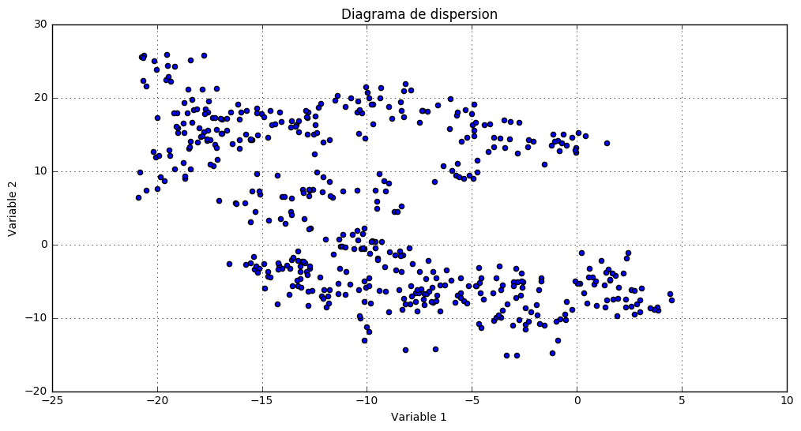

```python
variable1 = datos[:,0]
variable2 = datos[:,1]

fig, ax = plt.subplots(1, figsize=(12,6))
ax.set_title('Diagrama de dispersion')
ax.scatter(variable1, variable2, marker = 'o')    # puntitos azules

plt.xlabel('Variable 1')
plt.ylabel('Variable 2');

ax.grid(True)
```

## 1.5 Subgráficos

Permite representar información en una misma figura.

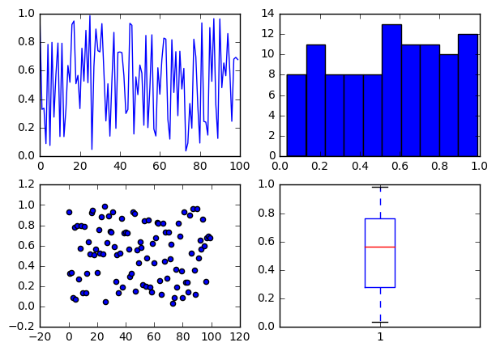

```python
# generamos datos aleatorios
x = np.arange(0, 100)
y = np.random.rand(100)  # 100 random numbers

# generamos 4 sub-gráficos
fig, ((ax1, ax2), (ax3, ax4)) = plt.subplots(2,2,figsize=(7,5))
ax1.plot(x, y)
ax2.hist(y)
ax3.scatter(x, y)
ax4.boxplot(y);
```

# References

- [Librería gráfica matplotlib](http://matplotlib.org/)
- [Python for Data Analysis](http://shop.oreilly.com/product/0636920023784.do)